# Questão 2 - Prova 2 - Econometria II

Aishameriane Schmidt

2 de novembro de 2017

# Introdução

Para esta questão escolhi os seguintes ativos:

- Starbucks Corporation (NASDAQ:SBUX)
- McDonald’s Corporation (NYSE:MCD)
- Domino’s Pizza, Inc. (NYSE:DPZ)
- PepsiCo, Inc. (NYSE:PEP)
- The Coca-Cola Co (NYSE:KO)

Escolhi empresas do ramo alimentício (na área de fast food) por acreditar que seus ativos vão estar de alguma forma reçacionados.

# Carregamento dos pacotes e download das séries

```r
list.of.packages <- c("quantmod","tseries","xts","ggplot2","highfrequency","vars","forecast","ustyc","MTS", "knitr", "stargazer", "rmgarch", "PerformanceAnalytics")
new.packages <- list.of.packages[!(list.of.packages %in% installed.packages()[,"Package"])]
if(length(new.packages)) install.packages(new.packages)
library(quantmod, quietly = T)
library(tseries, quietly = T)
library(ggplot2, quietly = T)
library(highfrequency, quietly = T)
library(vars, quietly = T)
library(forecast, quietly = T)
library(ustyc, quietly = T)
library(MTS, quietly = T)
library(reshape2, quietly = T)
library(xts, quietly = T)
library(rmgarch, quietly = T)
library(PerformanceAnalytics, quietly = T)
library(knitr, quietly = T)
library(stargazer, quietly = T)
```

# Baixa dados dos ativos e faz o gráfico das séries conjuntas

```r
symbols <- c("SBUX","MCD","DPZ","PEP","KO")
getSymbols(symbols, src = 'google', from = "2010-01-01",
             auto.assign = TRUE, warnings = FALSE)
```

```
## [1] "SBUX" "MCD"  "DPZ"  "PEP"  "KO"
```

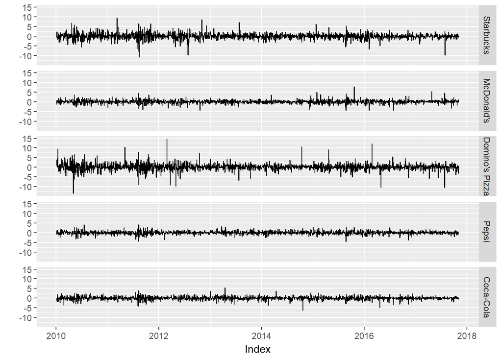

```r
prices <- merge(SBUX,MCD,DPZ,PEP,KO)
prices <- prices[,grepl( "Close" , names(prices) )]
colnames(prices) <- c("Starbucks", "McDonald's", "Domino's Pizza", "Pepsi", "Coca-Cola")
returns <- na.omit(Return.calculate(prices, method = "log"))*100

autoplot(returns)
```

No gráfico com as séries separadas, observamos que algumas séries aparentam ter um comportamento menos volátil que outras. Por exemplo, a série de retornos da Starbucks e Domino’s Pizza parecem ter mais clusters de alta volatilidade.

Para verificar, fiz o plot das séries juntas:

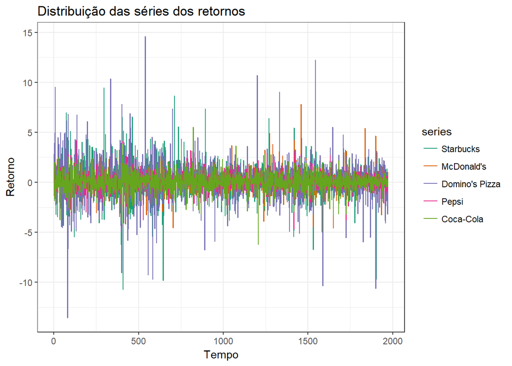

```r
autoplot(as.ts(returns), main = "Distribuição das séries dos retornos", xlab = "Tempo", ylab = "Retorno") +
  scale_colour_brewer(palette = "Dark2") +
  theme_bw()
```

De fato, ao observar as séries conjuntamente, há uma concentração dos retornos da Coca-Cola na região central do gráfico, em contraste com a grande quantidade de picos da série da Starbucks e da Domino’s Pizza, que detoam das demais séries.

Para a especificação da variância, optei por um modelo sGARCH(1,1) com uma distribuição de erros GED com assimetria. Essa escolha é em decorrência de termos visto em aula que a GED era a distribuição que melhor se adequava ao exercício feito e a assimetria eu escolhi porque já discutimos como é comum que a volatilidade não seja a mesma em períodos de alta do mercado em relação aos períodos de baixa, para séries financeiras.

Para fins de simplicidade, usei a mesma especificação para todos os 5 ativos. Idealmente poderia-se pensar em especificações diferentes para cada série, *mas idealmente eu teria mais de 48h para fazer e não estaria com os dois braços inflamados*.

```r
# meu garch vai seguir uma GED com assimetria
especificacao <- ugarchspec(distribution = "sged")
junta_tudo    <- multispec(c(especificacao, especificacao,especificacao,especificacao,especificacao))

# Faz a distribuição conjunta - eu escolhi uma t multivariada pelas caudas pesadas
dcc_espec     <- dccspec(junta_tudo, distribution = "mvt")
ajuste <- dccfit(dcc_espec, returns)
```

# Parâmetros estimados

Agora, vamos verificar os coeficientes calculados. Para os parâmetros, temos para cada uma das séries:

```r
# Mostra os parâmetros estimados
ajuste
```

```
##
## *---------------------------------*
## *          DCC GARCH Fit          *
## *---------------------------------*
##
## Distribution         :  mvt
## Model                :  DCC(1,1)
## No. Parameters       :  53
## [VAR GARCH DCC UncQ] : [0+40+3+10]
## No. Series           :  5
## No. Obs.             :  1971
## Log-Likelihood       :  -13094.18
## Av.Log-Likelihood    :  -6.64
##
## Optimal Parameters
## -----------------------------------
##                          Estimate  Std. Error    t value Pr(>|t|)
## [Starbucks].mu           0.077586    0.016372    4.73882 0.000002
## [Starbucks].ar1          0.808619    0.008837   91.50660 0.000000
## [Starbucks].ma1         -0.839117    0.009525  -88.09752 0.000000
## [Starbucks].omega        0.104306    0.052161    1.99967 0.045536
## [Starbucks].alpha1       0.093133    0.032437    2.87117 0.004090
## [Starbucks].beta1        0.860927    0.049739   17.30907 0.000000
## [Starbucks].skew         1.007632    0.028726   35.07770 0.000000
## [Starbucks].shape        1.197346    0.058676   20.40601 0.000000
## [McDonald's].mu          0.048678    0.008336    5.83926 0.000000
## [McDonald's].ar1         0.074333    0.007109   10.45667 0.000000
## [McDonald's].ma1        -0.133075    0.011127  -11.95945 0.000000
## [McDonald's].omega       0.020539    0.006532    3.14465 0.001663
## [McDonald's].alpha1      0.030313    0.005515    5.49617 0.000000
## [McDonald's].beta1       0.945622    0.010979   86.13265 0.000000
## [McDonald's].skew        0.931450    0.021798   42.73019 0.000000
## [McDonald's].shape       1.120242    0.056889   19.69180 0.000000
## [Domino's Pizza].mu      0.150847    0.004295   35.12424 0.000000
## [Domino's Pizza].ar1     0.051425    0.002123   24.21999 0.000000
## [Domino's Pizza].ma1    -0.099065    0.002679  -36.97651 0.000000
## [Domino's Pizza].omega   0.018514    0.004317    4.28867 0.000018
## [Domino's Pizza].alpha1  0.015994    0.001948    8.20895 0.000000
## [Domino's Pizza].beta1   0.976369    0.000468 2087.28534 0.000000
## [Domino's Pizza].skew    0.989351    0.009253  106.91643 0.000000
```

[output cut: 16 more lines]

```
## [Coca-Cola].shape        1.237328    0.060518   20.44552 0.000000
## [Joint]dcca1             0.009054    0.003230    2.80291 0.005064
## [Joint]dccb1             0.975582    0.012880   75.74285 0.000000
## [Joint]mshape            5.100927    0.167171   30.51324 0.000000
##
## Information Criteria
## ---------------------
##
## Akaike       13.341
## Bayes        13.491
## Shibata      13.339
## Hannan-Quinn 13.396
##
##
## Elapsed time : 53.89312
```

Para melhor visualizar melhor os resultados, fiz uma tabela separada com os coeficientes da média e da variância.

## Coeficientes da média condicional

```r
coef_media <- matrix(0, ncol = 5, nrow = 9)
colnames(coef_media) <- c("Starbucks", "McDonald's", "Domino's Pizza", "Pepsi", "Coca-Cola")
rownames(coef_media) <- c("mu", "D.P.", "p valor",
                          "AR", "D.P.", "p valor",
                          "MA", "D.P.", "p valor")

for (i in 1:3) {
  coef_media[(1+3*(i-1)),] <- round(c(ajuste@mfit$coef[i],
                      ajuste@mfit$coef[i+8],
                      ajuste@mfit$coef[i+2*8],
                      ajuste@mfit$coef[i+3*8],
                      ajuste@mfit$coef[i+4*8]),4)
}

for (i in 1:3) {
  coef_media[(2+3*(i-1)),] <- round(c(ajuste@mfit$matcoef[i,2],
                      ajuste@mfit$matcoef[i+8,2],
                      ajuste@mfit$matcoef[i+2*8,2],
                      ajuste@mfit$matcoef[i+3*8,2],
                      ajuste@mfit$matcoef[i+4*8,2]),4)
}

for (i in 1:3) {
  coef_media[(3+3*(i-1)),] <- round(c(ajuste@mfit$matcoef[i,4],
                      ajuste@mfit$matcoef[i+8,4],
                      ajuste@mfit$matcoef[i+2*8,4],
                      ajuste@mfit$matcoef[i+3*8,4],
                      ajuste@mfit$matcoef[i+4*8,4]),4)
}
coef_media <- as.data.frame(coef_media)
stargazer(coef_media, summary=FALSE, header = TRUE, type = 'html')
```

|  | Starbucks | McDonald’s | Domino’s Pizza | Pepsi | Coca-Cola |
| --- | --- | --- | --- | --- | --- |
| mu | 0.078 | 0.049 | 0.151 | 0.034 | 0.029 |
| D.P. | 0.016 | 0.008 | 0.004 | 0.012 | 0.016 |
| p valor | 0 | 0 | 0 | 0.005 | 0.074 |
| AR | 0.809 | 0.074 | 0.051 | -0.151 | 0.885 |
| D.P. | 0.009 | 0.007 | 0.002 | 0.021 | 0.922 |
| p valor | 0 | 0 | 0 | 0 | 0.337 |
| MA | -0.839 | -0.133 | -0.099 | 0.098 | -0.917 |
| D.P. | 0.010 | 0.011 | 0.003 | 0.023 | 0.793 |
| p valor | 0 | 0 | 0 | 0 | 0.247 |

## Coeficientes da variância

```r
coef_variancia <- matrix(0, ncol = 5, nrow = 9)
colnames(coef_variancia) <- c("Starbucks", "McDonald's", "Domino's Pizza", "Pepsi", "Coca-Cola")
rownames(coef_variancia) <- c("omega", "D.P.", "p valor",
                          "alpha", "D.P.", "p valor",
                          "beta", "D.P.", "p valor")

for (i in 1:3) {
  coef_variancia[(1+3*(i-1)),] <- round(c(ajuste@mfit$coef[i],
                      ajuste@mfit$coef[(i+3)+8],
                      ajuste@mfit$coef[(i+3)+2*8],
                      ajuste@mfit$coef[(i+3)+3*8],
                      ajuste@mfit$coef[(i+3)+4*8]),4)
}

for (i in 1:3) {
  coef_variancia[(2+3*(i-1)),] <- round(c(ajuste@mfit$matcoef[i,2],
                      ajuste@mfit$matcoef[(i+3)+8,2],
                      ajuste@mfit$matcoef[(i+3)+2*8,2],
                      ajuste@mfit$matcoef[(i+3)+3*8,2],
                      ajuste@mfit$matcoef[(i+3)+4*8,2]),4)
}

for (i in 1:3) {
  coef_variancia[(3+3*(i-1)),] <- round(c(ajuste@mfit$matcoef[i,4],
                      ajuste@mfit$matcoef[(i+3)+8,4],
                      ajuste@mfit$matcoef[(i+3)+2*8,4],
                      ajuste@mfit$matcoef[(i+3)+3*8,4],
                      ajuste@mfit$matcoef[(i+3)+4*8,4]),4)
}

stargazer(coef_variancia, summary=FALSE, header = TRUE, type = 'html')
```

[output not shown]

```r
# DCC 1,1 significa que a autocorrelação segue um AR(1)
```

Com relação aos coeficientes do modelo para variância condicional, tanto a Pepsi como a Coca-Cola apresentaram como significativo (a um nível de 5% de significância) apenas o coeficiente beta, correspondente à “média móvel” do modelo GARCH.

# Variâncias condicionais

Para analisar as variâncias condicionais, primeiro utilizamos a função `rcov()` e depois plotamos os gráficos.

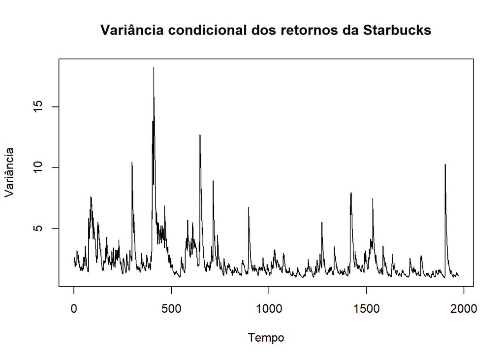

```r
# faz a matriz de covariâncias
matriz_cov <- rcov(ajuste)

# Na diagonal estão as covariâncias, por exemplo para starbucks
ts.plot(matriz_cov[1,1,], main = "Variância condicional dos retornos da Starbucks", xlab = "Tempo", ylab = "Variância")
```

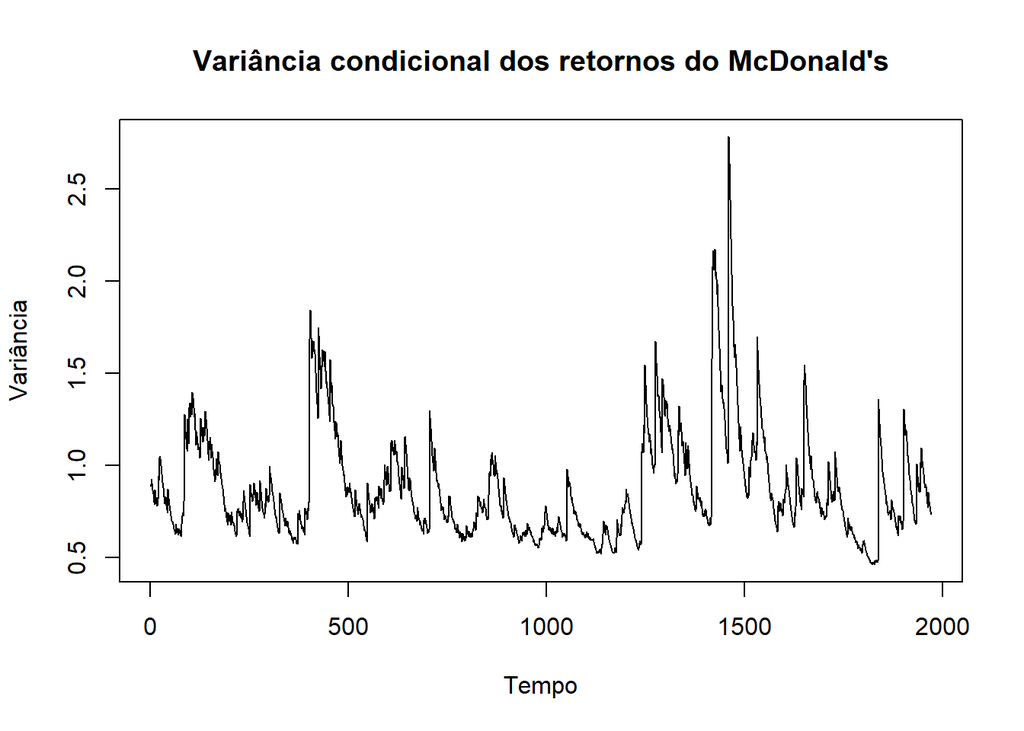

```r
ts.plot(matriz_cov[2,2,], main = "Variância condicional dos retornos do McDonald's", xlab = "Tempo", ylab = "Variância")
```

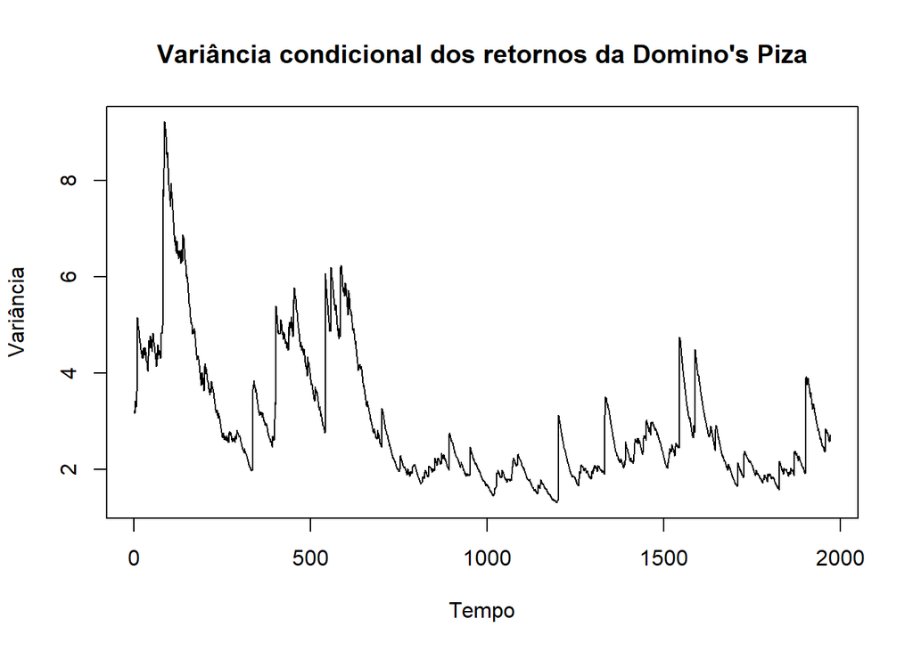

```r
ts.plot(matriz_cov[3,3,], main = "Variância condicional dos retornos da Domino's Piza", xlab = "Tempo", ylab = "Variância")
```

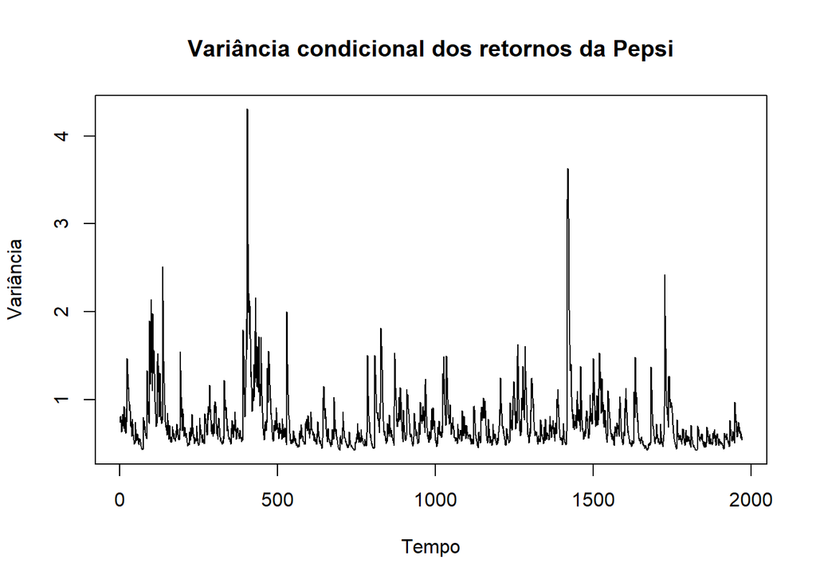

```r
ts.plot(matriz_cov[4,4,], main = "Variância condicional dos retornos da Pepsi", xlab = "Tempo", ylab = "Variância")
```

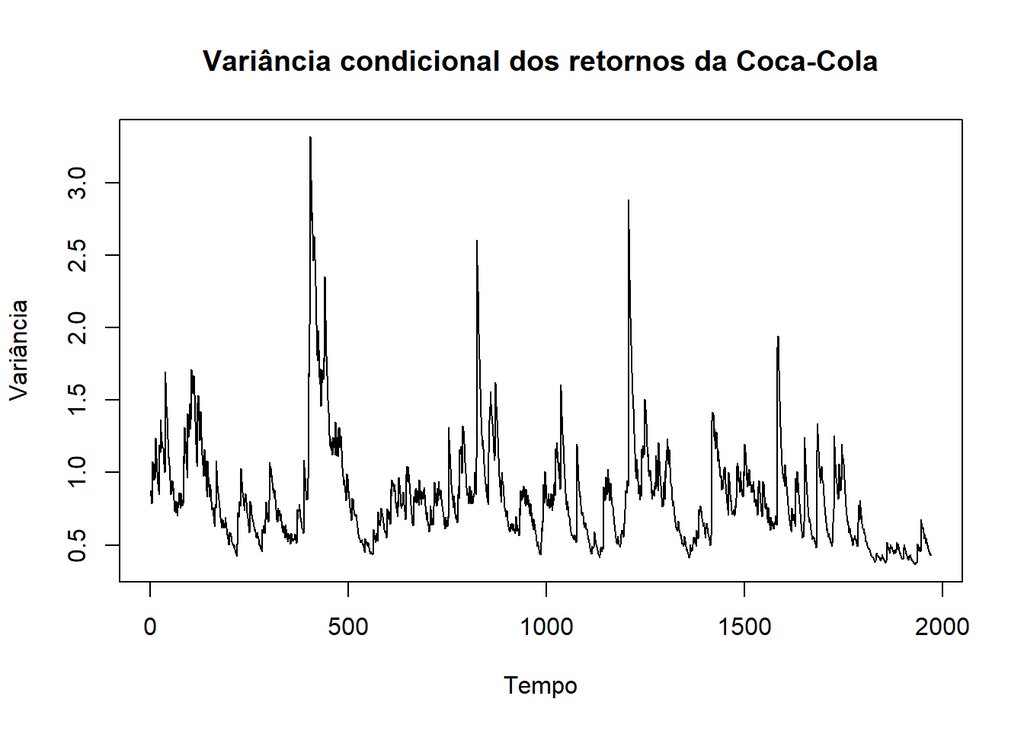

```r
ts.plot(matriz_cov[5,5,], main = "Variância condicional dos retornos da Coca-Cola", xlab = "Tempo", ylab = "Variância")
```

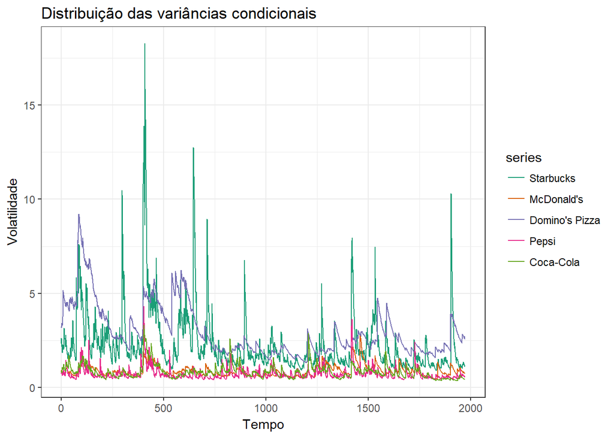

```r
# Vou montar um data frame com as séries para plotar melhor
variancias <- as.data.frame(cbind(as.ts(matriz_cov[1,1,]), as.ts(matriz_cov[2,2,]), as.ts(matriz_cov[3,3,]), as.ts(matriz_cov[4,4,]), as.ts(matriz_cov[5,5,])))

colnames(variancias) <- c("Starbucks", "McDonald's", "Domino's Pizza", "Pepsi", "Coca-Cola")

autoplot(as.ts(variancias), main = "Distribuição das variâncias condicionais", xlab = "Tempo", ylab = "Volatilidade") +
  scale_colour_brewer(palette = "Dark2") +
  theme_bw()
```

```r
#autoplot(cbind(as.ts(matriz_cov[1,1,]), as.ts(matriz_cov[2,2,]), as.ts(matriz_cov[3,3,]), as.ts(matriz_cov[4,4,]), as.ts(matriz_cov[5,5,])))
```

# Correlações condicionais

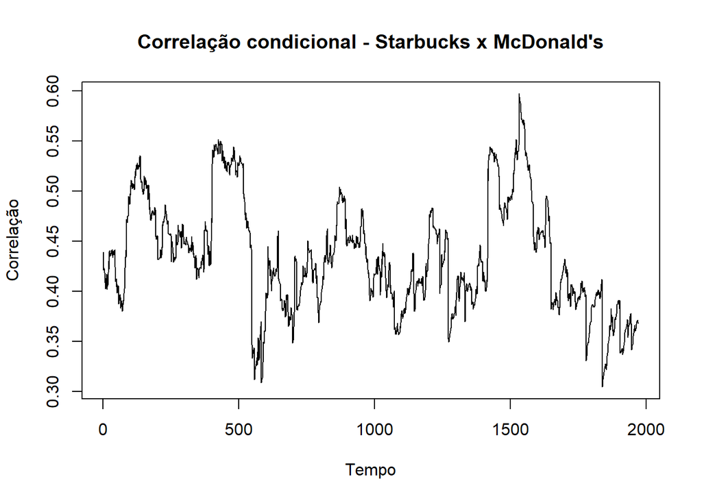

```r
# Para a correlação condicional precisamos primeiro montar a matriz
matriz_cor <- rcor(ajuste)
# na linha 1 e coluna 2 tem a correlação da starbucks com o mc donalds
ts.plot(matriz_cor[1,2,], main = "Correlação condicional - Starbucks x McDonald's", xlab = "Tempo", ylab = "Correlação")
```

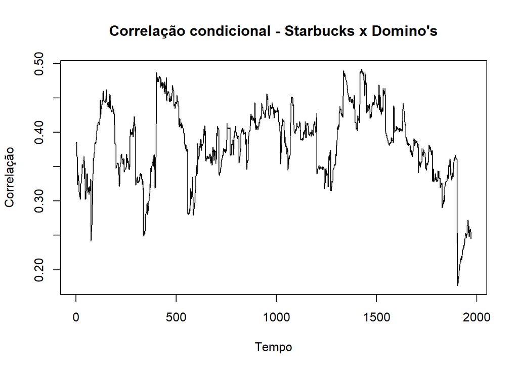

```r
ts.plot(matriz_cor[1,3,], main = "Correlação condicional - Starbucks x Domino's", xlab = "Tempo", ylab = "Correlação")
```

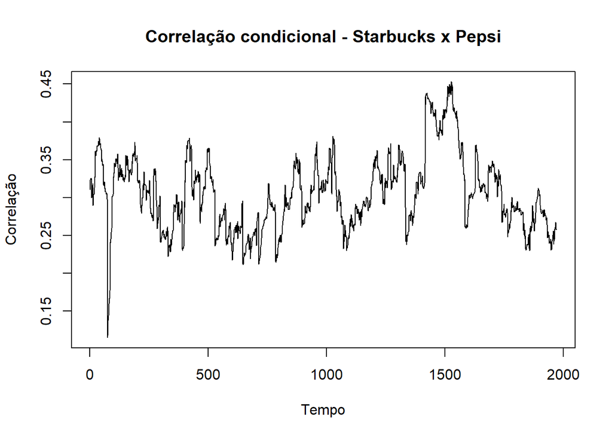

```r
ts.plot(matriz_cor[1,4,], main = "Correlação condicional - Starbucks x Pepsi", xlab = "Tempo", ylab = "Correlação")
```

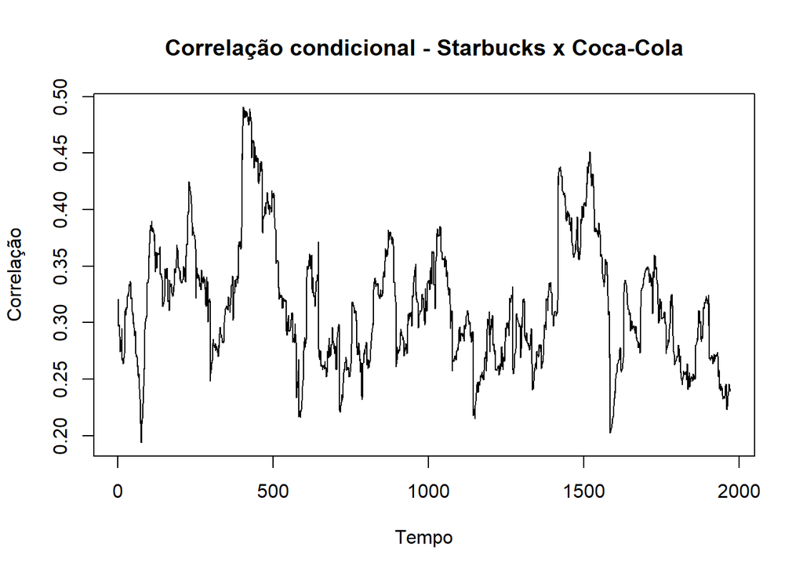

```r
ts.plot(matriz_cor[1,5,], main = "Correlação condicional - Starbucks x Coca-Cola", xlab = "Tempo", ylab = "Correlação")
```

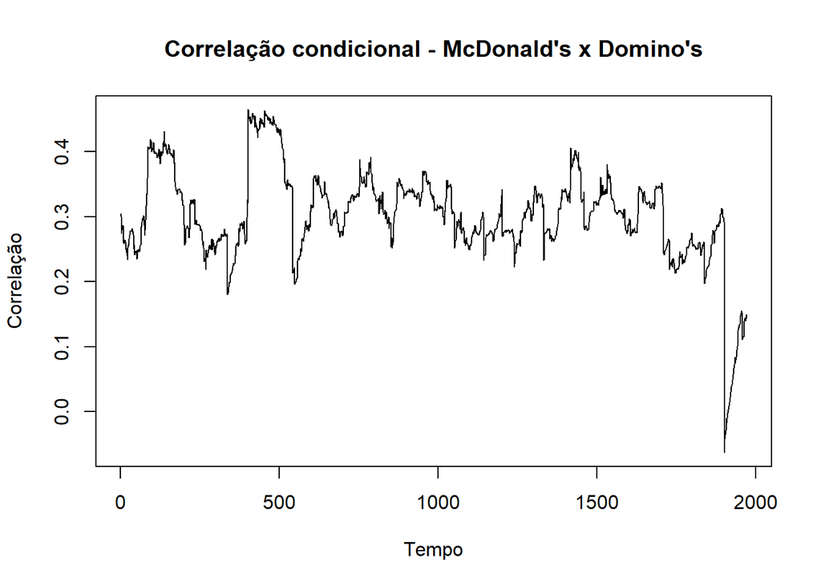

```r
ts.plot(matriz_cor[2,3,], main = "Correlação condicional - McDonald's x Domino's", xlab = "Tempo", ylab = "Correlação")
```

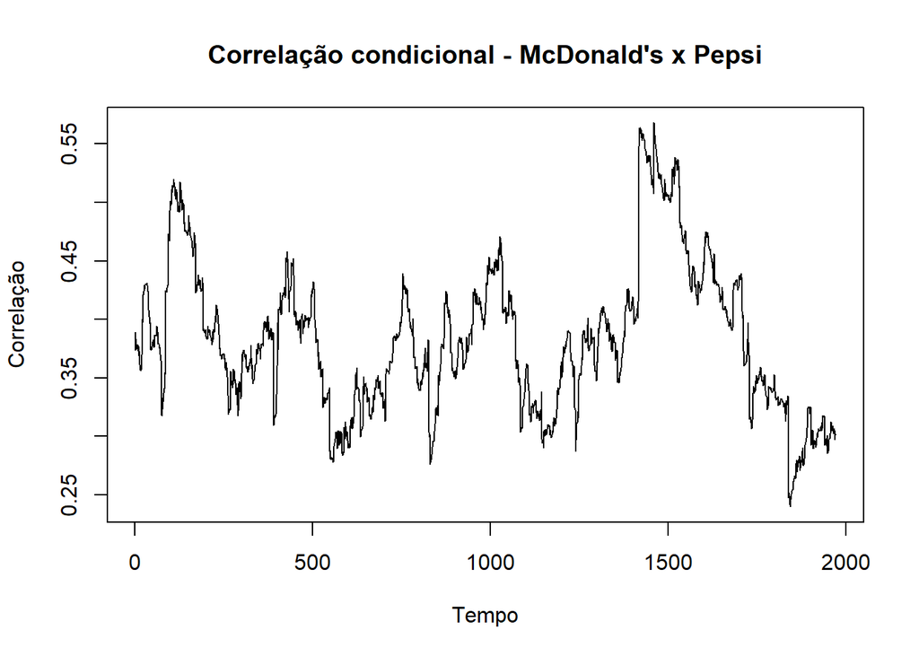

```r
ts.plot(matriz_cor[2,4,], main = "Correlação condicional - McDonald's x Pepsi", xlab = "Tempo", ylab = "Correlação")
```